# DAanalysis_FAPROTAX

2026-01-09

# Workflow to this script:

1. Pre-processing_16S.Rmd
2. rarefaction_16S.Rmd
3. NMDS_16S.Rmd
4. envfit_ASV_16S.Rmd
5. BVOC_preprocessing.Rmd
6. envfit_BVOC_LODrev.Rmd
7. FAPROTAX_prep
8. FAPROTAX_analysis.Rmd
9. clean_tsv_fapro.R
10. DAanalysis_FAPROTAX.Rmd (this file)

# path to raw-data directory (change “path” to your raw-data directory)

```r
# create "path" file, and define "path" as your raw-data directory(character vector) in the file
# "path" is raw-data directory, and "path_out" is output file directory

source("../scripts/path.R")
```

# source codes

```r
source("../R/occurrence.R")
source("../R/plot_top_taxa.R")
```

# plot theme

```r
mytheme <-theme(text = element_text(color = "black"),
                axis.text = element_text(color = "black")
                )
```

# data import

**data import**

## ps_object

```r
load(file = paste0(path_out, "/231202_Sugi_phyllosphere_June_16S/processed_data/ps_fapro_nov.Rdata"))
```

## BVOC

```r
#read VOC data
load(file = paste0(path_out, "/data/Sugi/BVOC/exp_Terpene_2209to2408_LODrev_nolod.Rdata"))
load(file = paste0(path_out, "/data/Sugi/BVOC/exp_Terpene_2209to2408_LODrev_log.Rdata"))

#extract the data for June 2023
BVOC_2306 <- exp_Ohta_nolod %>% subset(Month == "2306")
BVOC_2306_log <- exp_Ohta_log %>% subset(Month == "2306")

#Longifolene is not detected in the June 2023 samples, so remove it
BVOC_2306 <- BVOC_2306[, -which(colnames(BVOC_2306) == "Longifolene")]
BVOC_2306 <- BVOC_2306_log[, -which(colnames(BVOC_2306_log) == "Longifolene")]

#remove beta-Caryophyllene from the dataframe
bCary <- which("beta-Caryophyllene" == colnames(BVOC_2306_log)) #the column number of beta-Caryophyllene
BVOC_2306_log_rm <- assay(BVOC_2306_log)[, -bCary] #remove beta-Caryophyllene
```

```r
#calculate log-transformed total BVOC- and MTs emission
BVOC_2306_total_log <- data.frame(total = log(rowSums(assay(BVOC_2306)), base = 10)) %>%
  rownames_to_column(var = "sampleID")
MT_2306_log <- data.frame(MTs = log(rowSums(assay(BVOC_2306[, BVOC_2306$mol_weight == "Mono"])) + 1, base = 10)) %>%
  rownames_to_column(var = "sampleID")
SQT_2306_log <- data.frame(SQT = log(rowSums(assay(BVOC_2306[, BVOC_2306$mol_weight == "Sesqui"])) + 1, base = 10)) %>%
  rownames_to_column(var = "sampleID")
DT_2306_log <- data.frame(DT = log(rowSums(assay(BVOC_2306[, BVOC_2306$mol_weight == "Di"])) + 1, base = 10)) %>%
  rownames_to_column(var = "sampleID")

#merge BVOC data
all_2306_log <- BVOC_2306_log_rm %>%
  rownames_to_column(var = "sampleID") %>%
  full_join(BVOC_2306_total_log, by = "sampleID") %>%
  full_join(MT_2306_log, by = "sampleID") %>%
  full_join(SQT_2306_log, by = "sampleID") %>%
  full_join(DT_2306_log, by = "sampleID")

# PCA results
load(paste0(path_out, "/data/Sugi/BVOC/pca_BVOC_2306_log_LODrev.Rdata"))
BVOC_pca <- data.frame(pca_BVOC_log_rm_LODrev$x)
colnames(BVOC_pca) <- paste(colnames(BVOC_pca), "ter", sep = "_")
BVOC_pca <- BVOC_pca %>%
  rownames_to_column(var = "sampleID")

# merge PC1:3 to all_2306_log
all_2306_log <- all_2306_log %>%
  left_join(BVOC_pca %>% dplyr::select(sampleID, PC1_ter, PC2_ter, PC3_ter), by = "sampleID") %>%
  dplyr::filter(!is.na(PC1_ter)) %>% # remove samples with NA PC1_ter values (microbe data not available)
  dplyr::mutate(sampleID = paste(sapply(lapply(str_split(sampleID, "_"), `[`, 1:3), paste0, collapse = "_"),
                                 substr(replace_na(sapply(str_split(sampleID, "_"), `[`, 4), "01"), 2, 2),
                                 sep = "_")
                )
```

```r
#merge metadata
metadata <- data.frame(sample_data(ps_fapro_nov))
metadata <- metadata %>%
  dplyr::mutate(sampleID = paste(paste0(substr(site, 1, 1), "2306"),
                                 samplename, sep = "_")
                )

metadata <- metadata %>%
  left_join(all_2306_log, by = "sampleID")
rownames(metadata) <- formatC(as.numeric(rownames(metadata)), width = 4, flag = "0")

# add to phyloseq
sample_data(ps_fapro_nov) <- sample_data(metadata)
```

# MaAsLin2

**DA analysis with MaAsLin2**

## Whole

```r
DA_res <- Maaslin2(input_data = as.data.frame(t(otu_table(ps_fapro_nov)))[, -29],
                   input_metadata = data.frame(sample_data(ps_fapro_nov)) %>%
                     dplyr::select(site),
                   output = paste0(path_out, "/231202_Sugi_phyllosphere_June_16S/processed_data/DA/Maaslin2/Whole"),
                   fixed_effects = c("site"),
                   random_effects = NULL,
                   analysis_method = "LM",
                   transform = "LOG",
                   normalization = "NONE",
                   min_abundance = 0.0,
                   min_prevalence = 0.1,
                   max_significance = 0.05,
                   reference = c("site,Tsukuba"),
                   plot_heatmap = TRUE,
                   plot_scatter = TRUE)
```

[output not shown]

```
## 2026-01-15 13:39:40.874568 INFO::Creating boxplot for categorical data, site vs FG067
```

```
## 2026-01-15 13:39:41.082968 INFO::Creating boxplot for categorical data, site vs FG048
```

```r
signif <- read_tsv(file = paste0(path_out, "/231202_Sugi_phyllosphere_June_16S/processed_data/DA/Maaslin2/Whole/significant_results.tsv"))
fitdata_tf <- read_tsv(file = paste0(path_out, "/231202_Sugi_phyllosphere_June_16S/processed_data/DA/Maaslin2/Whole/features/filtered_data_norm_transformed.tsv"))
fitdata_tf <- data.frame(fitdata_tf) %>%
  column_to_rownames(var = "feature")

signif <-signif %>%
  left_join(data.frame(tax_table(ps_fapro_nov)) %>%
              rownames_to_column(var = "feature"),
            by = "feature")

show(signif)
```

```
## # A tibble: 3 × 10
##   feature metadata value      coef stderr     N N.not.0     pval    qval group
##   <chr>   <chr>    <chr>     <dbl>  <dbl> <dbl>   <dbl>    <dbl>   <dbl> <chr>
## 1 FG034   site     Kawatabi  1.45   0.381   108      93 0.000227 0.00340 nitrog…
## 2 FG067   site     Kawatabi  1.18   0.327   108      76 0.000475 0.00357 hydroc…
## 3 FG048   site     Kawatabi -0.589  0.183   108     108 0.00171  0.00856 aerobi…
```

**The RAs of some metabolism-related functions are positively associated with the Kawatabi common garden.**  
**The RA of aerobic chemoheterotrophy was negatively assoicated with the Kawtabi common garden.**

## Kawatabi

```r
ps_fapro_k <- subset_samples(ps_fapro_nov, site == "Kawatabi")

DA_res_k <- Maaslin2(input_data = as.data.frame(t(otu_table(ps_fapro_k)))[, -29],
                     input_metadata = data.frame(sample_data(ps_fapro_k)) %>%
                       dplyr::select(PC1_clim),
                     output = paste0(path_out, "/231202_Sugi_phyllosphere_June_16S/processed_data/DA/Maaslin2/Kawatabi"),
                     fixed_effects = c("PC1_clim"),
                     random_effects = NULL,
                     analysis_method = "LM",
                     transform = "LOG",
                     normalization = "NONE",
                     min_abundance = 0.0,
                     min_prevalence = 0.1,
                     max_significance = 0.05,
                     plot_heatmap = TRUE,
                     plot_scatter = FALSE)
```

[output not shown]

```r
signif_k <- read_tsv(file = paste0(path_out, "/231202_Sugi_phyllosphere_June_16S/processed_data/DA/Maaslin2/Kawatabi/significant_results.tsv"))
fitdata_tf_k <- read_tsv(file = paste0(path_out, "/231202_Sugi_phyllosphere_June_16S/processed_data/DA/Maaslin2/Kawatabi/features/filtered_data_norm_transformed.tsv"))
fitdata_tf_k <- data.frame(fitdata_tf_k) %>%
  column_to_rownames(var = "feature")

signif_k <- signif_k %>%
  left_join(data.frame(tax_table(ps_fapro_k)) %>%
              rownames_to_column(var = "feature"),
            by = "feature")

show(signif_k)
```

```
## # A tibble: 6 × 10
##   feature metadata value      coef stderr     N N.not.0      pval     qval group
##   <chr>   <chr>    <chr>     <dbl>  <dbl> <dbl>   <dbl>     <dbl>    <dbl> <chr>
## 1 FG048   PC1_clim PC1_clim -0.496 0.109     58      58 0.0000271 0.000379 aero…
## 2 FG074   PC1_clim PC1_clim  0.912 0.252     58      46 0.000630  0.00441  intr…
## 3 FG090   PC1_clim PC1_clim -1.06  0.325     58      44 0.00182   0.00851  ureo…
## 4 FG067   PC1_clim PC1_clim  0.500 0.167     58      47 0.00407   0.0142   hydr…
## 5 FG092   PC1_clim PC1_clim -0.221 0.0891    58      58 0.0160    0.0449   chem…
## 6 FG034   PC1_clim PC1_clim  0.324 0.136     58      54 0.0201    0.0469   nitr…
```

**The RAs of metabolism-related functions and intracellualr parasites were positively associated with climatic PC1 in Kawatabi.**  
**The RAs of chemoheterotrophy and ureolysis were negatively associated with climatic PC1.**

### BVOCs

```r
ps_fapro_VOC <- subset_samples(ps_fapro_k, !is.na(PC1_ter))

DA_res_VOC <- Maaslin2(input_data = as.data.frame(t(otu_table(ps_fapro_VOC)))[, -29],
                     input_metadata = data.frame(sample_data(ps_fapro_VOC)) %>%
                       dplyr::select(PC1_ter, PC2_ter, PC3_ter),
                     output = paste0(path_out, "/231202_Sugi_phyllosphere_June_16S/processed_data/DA/Maaslin2/BVOC"),
                     fixed_effects = c("PC1_ter", "PC2_ter", "PC3_ter"),
                     random_effects = NULL,
                     analysis_method = "LM",
                     transform = "LOG",
                     normalization = "NONE",
                     min_abundance = 0.0,
                     min_prevalence = 0.1,
                     max_significance = 0.1, # lower threshold to acount for small sample size
                     plot_heatmap = TRUE,
                     plot_scatter = FALSE)
```

[output not shown]

```r
signif_v <- read_tsv(file = paste0(path_out, "/231202_Sugi_phyllosphere_June_16S/processed_data/DA/Maaslin2/BVOC/significant_results.tsv"))
all_v <- read_tsv(file = paste0(path_out, "/231202_Sugi_phyllosphere_June_16S/processed_data/DA/Maaslin2/BVOC/all_results.tsv"))
fitdata_tf_v <- read_tsv(file = paste0(path_out, "/231202_Sugi_phyllosphere_June_16S/processed_data/DA/Maaslin2/BVOC/features/filtered_data_norm_transformed.tsv"))
fitdata_tf_v <- data.frame(fitdata_tf_v) %>%
  column_to_rownames(var = "feature")

signif_v <- signif_v %>%
  left_join(data.frame(tax_table(ps_fapro_VOC)) %>%
              rownames_to_column(var = "feature"),
            by = "feature")
all_v <- all_v %>%
  left_join(data.frame(tax_table(ps_fapro_VOC)) %>%
              rownames_to_column(var = "feature"),
            by = "feature")

show(signif_v)
```

```
## # A tibble: 2 × 10
##   feature metadata value    coef stderr     N N.not.0     pval   qval group
##   <chr>   <chr>    <chr>   <dbl>  <dbl> <dbl>   <dbl>    <dbl>  <dbl> <chr>
## 1 FG048   PC3_ter  PC3_ter 0.721  0.173    25      25 0.000428 0.0167 aerobic_c…
## 2 FG034   PC1_ter  PC1_ter 0.602  0.183    25      23 0.00348  0.0678 nitrogen_…
```

**The RAs of nitrogen fixation (positively associated with climatic PC1) was positively associated with terpene PC1 (less MTs emission) in Kawtabi.**  
**The RAs of aerobic chemoheterotrophy was positively associated with terpene PC3 (more beta-Farnesene emissions).**

## Tsukuba

```r
ps_fapro_t <- subset_samples(ps_fapro_nov, site == "Tsukuba")

DA_res_t <- Maaslin2(input_data = as.data.frame(t(otu_table(ps_fapro_t)))[, -29],
                     input_metadata = data.frame(sample_data(ps_fapro_t)) %>%
                       dplyr::select(PC1_clim),
                     output = paste0(path_out, "/231202_Sugi_phyllosphere_June_16S/processed_data/DA/Maaslin2/Tsukuba"),
                     fixed_effects = c("PC1_clim"),
                     random_effects = NULL,
                     analysis_method = "LM",
                     transform = "LOG",
                     normalization = "NONE",
                     min_abundance = 0.0,
                     min_prevalence = 0.1,
                     max_significance = 0.05,
                     plot_heatmap = TRUE,
                     plot_scatter = FALSE)
```

[output not shown]

```r
signif_t <- read_tsv(file = paste0(path_out, "/231202_Sugi_phyllosphere_June_16S/processed_data/DA/Maaslin2/Tsukuba/significant_results.tsv"))
all_t <- read_tsv(file = paste0(path_out, "/231202_Sugi_phyllosphere_June_16S/processed_data/DA/Maaslin2/Tsukuba/all_results.tsv"))
show(signif_t)
```

```
## # A tibble: 0 × 9
## # ℹ 9 variables: feature <chr>, metadata <chr>, value <chr>, coef <chr>,
## #   stderr <chr>, N <chr>, N.not.0 <chr>, pval <chr>, qval <chr>
```

```r
show(all_t)
```

```
## # A tibble: 14 × 9
##    feature metadata value        coef stderr     N N.not.0  pval  qval
##    <chr>   <chr>    <chr>       <dbl>  <dbl> <dbl>   <dbl> <dbl> <dbl>
##  1 FG009   PC1_clim PC1_clim  0.121    0.315    50       8 0.703 0.957
##  2 FG033   PC1_clim PC1_clim -0.0823   0.472    50      15 0.862 0.957
##  3 FG034   PC1_clim PC1_clim -0.0274   0.332    50      39 0.935 0.957
##  4 FG047   PC1_clim PC1_clim -0.0306   0.533    50      19 0.954 0.957
##  5 FG048   PC1_clim PC1_clim  0.00958  0.136    50      50 0.944 0.957
##  6 FG061   PC1_clim PC1_clim  0.101    0.401    50      25 0.802 0.957
##  7 FG065   PC1_clim PC1_clim  0.221    0.397    50      11 0.580 0.957
##  8 FG067   PC1_clim PC1_clim -0.0595   0.252    50      29 0.815 0.957
##  9 FG071   PC1_clim PC1_clim -0.186    0.381    50       6 0.628 0.957
## 10 FG074   PC1_clim PC1_clim  0.195    0.476    50      35 0.684 0.957
## 11 FG076   PC1_clim PC1_clim -0.267    0.485    50      15 0.586 0.957
## 12 FG088   PC1_clim PC1_clim -0.255    0.343    50       7 0.461 0.957
## 13 FG090   PC1_clim PC1_clim -0.296    0.372    50      35 0.430 0.957
## 14 FG092   PC1_clim PC1_clim -0.00705  0.131    50      50 0.957 0.957
```

**No functions were significantly associated with the climatic PC1 in Tsukuba.**  
**See details of the entire analysis and Kawatabi-specific analysis.**

# Results

```r
show(signif)
```

```
## # A tibble: 3 × 10
##   feature metadata value      coef stderr     N N.not.0     pval    qval group
##   <chr>   <chr>    <chr>     <dbl>  <dbl> <dbl>   <dbl>    <dbl>   <dbl> <chr>
## 1 FG034   site     Kawatabi  1.45   0.381   108      93 0.000227 0.00340 nitrog…
## 2 FG067   site     Kawatabi  1.18   0.327   108      76 0.000475 0.00357 hydroc…
## 3 FG048   site     Kawatabi -0.589  0.183   108     108 0.00171  0.00856 aerobi…
```

```r
show(signif_k)
```

```
## # A tibble: 6 × 10
##   feature metadata value      coef stderr     N N.not.0      pval     qval group
##   <chr>   <chr>    <chr>     <dbl>  <dbl> <dbl>   <dbl>     <dbl>    <dbl> <chr>
## 1 FG048   PC1_clim PC1_clim -0.496 0.109     58      58 0.0000271 0.000379 aero…
## 2 FG074   PC1_clim PC1_clim  0.912 0.252     58      46 0.000630  0.00441  intr…
## 3 FG090   PC1_clim PC1_clim -1.06  0.325     58      44 0.00182   0.00851  ureo…
## 4 FG067   PC1_clim PC1_clim  0.500 0.167     58      47 0.00407   0.0142   hydr…
## 5 FG092   PC1_clim PC1_clim -0.221 0.0891    58      58 0.0160    0.0449   chem…
## 6 FG034   PC1_clim PC1_clim  0.324 0.136     58      54 0.0201    0.0469   nitr…
```

```r
show(signif_v)
```

```
## # A tibble: 2 × 10
##   feature metadata value    coef stderr     N N.not.0     pval   qval group
##   <chr>   <chr>    <chr>   <dbl>  <dbl> <dbl>   <dbl>    <dbl>  <dbl> <chr>
## 1 FG048   PC3_ter  PC3_ter 0.721  0.173    25      25 0.000428 0.0167 aerobic_c…
## 2 FG034   PC1_ter  PC1_ter 0.602  0.183    25      23 0.00348  0.0678 nitrogen_…
```

**Overall, the reverse of homeground advantage effect may exist in the climate clines of bacterial functions. That is, functions that were abundant in the warmer gardens were less abundant on trees from warmer population.**

## scatter plot

###Kawatabi

```r
pldata_tf_k <- fitdata_tf_k %>%
  dplyr::select(signif_k$feature) %>%
  rownames_to_column(var = "rownames") %>%
  left_join(data.frame(sample_data(ps_fapro_k)) %>%
              rownames_to_column(var = "rownames") %>%
              dplyr::select(rownames, PC1_clim),
            by = "rownames") %>%
  pivot_longer(names_to = "feature", values_to = "log2RA", cols = -c(rownames, PC1_clim))
```

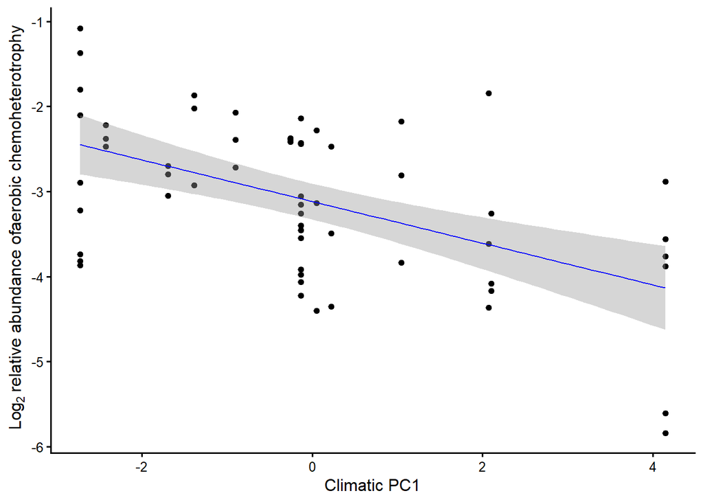

```r
features_sig <- signif_k$feature
plots <- list()

for (i in 1:length(features_sig)) {
  p <- ggplot(data = pldata_tf_k %>% dplyr::filter(feature == features_sig[i]),
              mapping = aes(x = PC1_clim, y = log2RA)) +
    geom_point() +
    stat_smooth(method = "glm",
                linewidth = 0.5,
                color = 'blue',
                na.rm = TRUE) +
    xlab("Climatic PC1") +
    ylab(bquote({Log[2]} ~ "relative abundance of" ~ .(gsub("_", " ", signif_k[signif_k$feature == features_sig[i], ]$group)))) +
    theme_classic(base_size = 12) + mytheme

  plots[[i]] <- p
  ggsave(filename = paste0(path_out,
                           "/231202_Sugi_phyllosphere_June_16S/processed_data/DA/Maaslin2/Kawatabi/figures/",
                           signif_k[signif_k$feature == features_sig[i], ]$group, ".png"),
         plot = p,
         width = 160, height = 120, units = "mm", dpi = 300)
}
names(plots) <- signif_k$group
plots[["aerobic_chemoheterotrophy"]]
```

### BVOC

```r
pldata_tf_v <- fitdata_tf_v %>%
  dplyr::select(signif_v$feature) %>%
  rownames_to_column(var = "rownames") %>%
  left_join(data.frame(sample_data(ps_fapro_VOC)) %>%
              rownames_to_column(var = "rownames") %>%
              dplyr::select(rownames, PC1_ter, PC3_ter),
            by = "rownames") %>%
  pivot_longer(names_to = "feature", values_to = "log2RA", cols = -c(rownames, PC1_ter, PC3_ter))
```

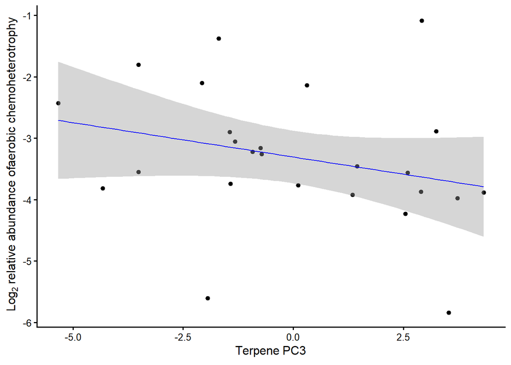

```r
features_sig_v <- signif_v %>%
  dplyr::select(feature, value)
plots_v <- list()

for (i in 1:length(features_sig_v)) {
  p <- ggplot(data = pldata_tf_v %>% dplyr::filter(feature == features_sig_v[i, ]$feature),
              mapping = aes(x = eval(parse(text = features_sig_v[i, ]$value)), y = log2RA)) +
    geom_point() +
    stat_smooth(method = "glm",
                linewidth = 0.5,
                color = 'blue',
                na.rm = TRUE) +
    xlab(bquote("Terpene" ~
                  .(sapply(
                    str_split(features_sig_v[i, ]$value, "_"), `[`, 1)
                    )
                )
         ) +
    ylab(bquote({Log[2]} ~
                  "relative abundance of" ~
                  .(
                    gsub("_", " ", signif_v[signif_v$feature == features_sig_v[i, ]$feature, ]$group)
                    )
                )
         ) +
    theme_classic(base_size = 12) + mytheme

  plots_v[[i]] <- p
  ggsave(filename = paste0(path_out,
                           "/231202_Sugi_phyllosphere_June_16S/processed_data/DA/Maaslin2/BVOC/figures/",
                           signif_v[signif_v$feature == features_sig_v[i, ]$feature, ]$group, ".png"),
         plot = p,
         width = 160, height = 120, units = "mm", dpi = 300)
}
plots_v[[1]]
```

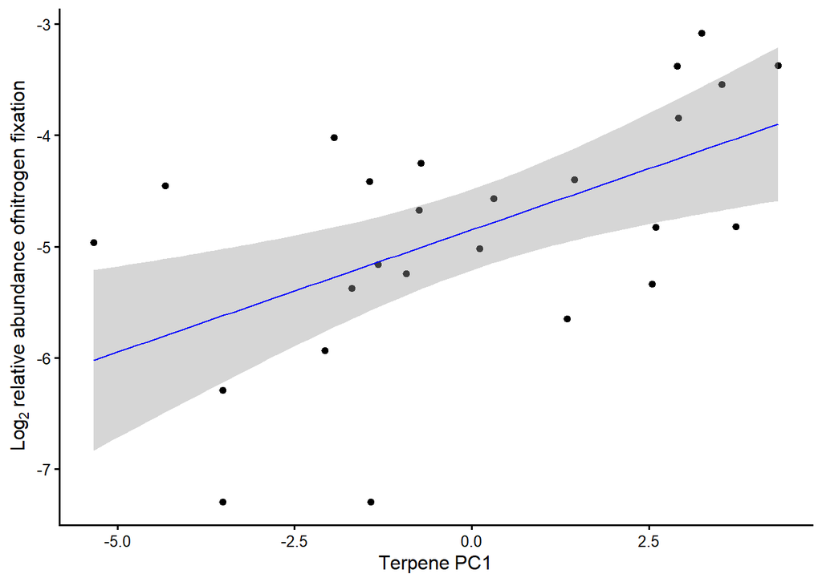

```r
plots_v[[2]]
```

**Plots_v[[1]] is a wrong plot. Saved plot is correct. Cause unknown.**  
**Below is the correct plot.**

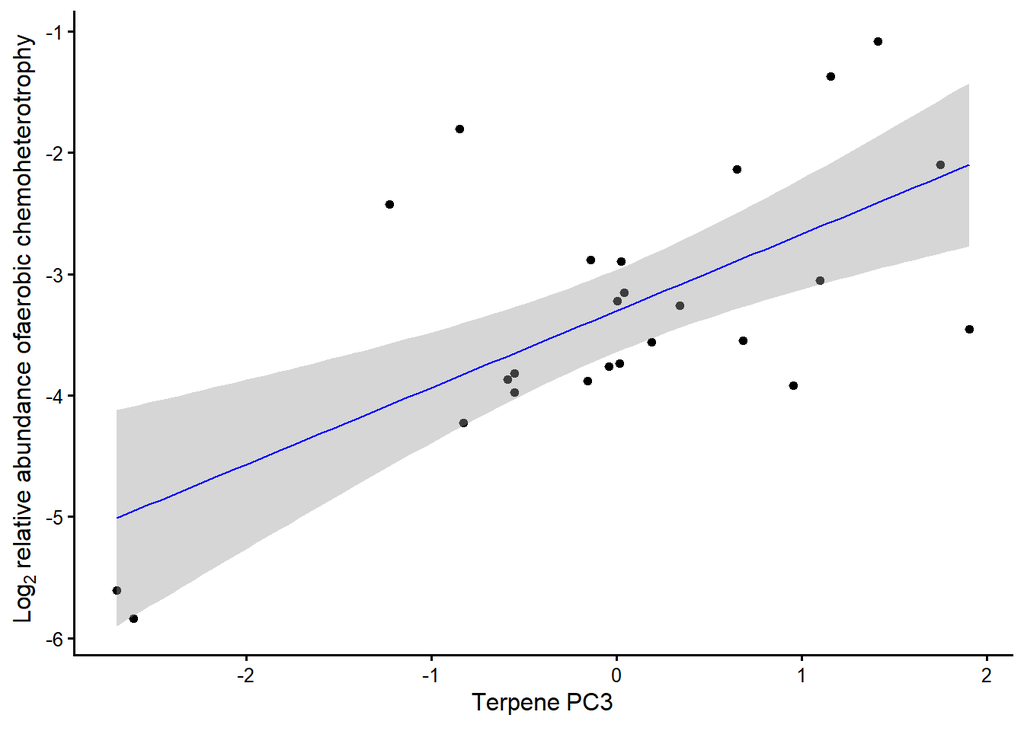

```r
p <- ggplot(data = pldata_tf_v %>% dplyr::filter(feature == features_sig_v[1, ]$feature),
              mapping = aes(x = eval(parse(text = features_sig_v[1, ]$value)), y = log2RA)) +
    geom_point() +
    stat_smooth(method = "glm",
                linewidth = 0.5,
                color = 'blue',
                na.rm = TRUE) +
    xlab(bquote("Terpene" ~
                  .(sapply(
                    str_split(features_sig_v[1, ]$value, "_"), `[`, 1)
                    )
                )
         ) +
    ylab(bquote({Log[2]} ~
                  "relative abundance of" ~
                  .(
                    gsub("_", " ", signif_v[signif_v$feature == features_sig_v[1, ]$feature, ]$group)
                    )
                )
         ) +
    theme_classic(base_size = 12) + mytheme

show(p)
```